# Random Effects ANCOVA

## ANCOVA

> “What’s in a name? That which we call a rose  
> By any other name would smell as sweet.”

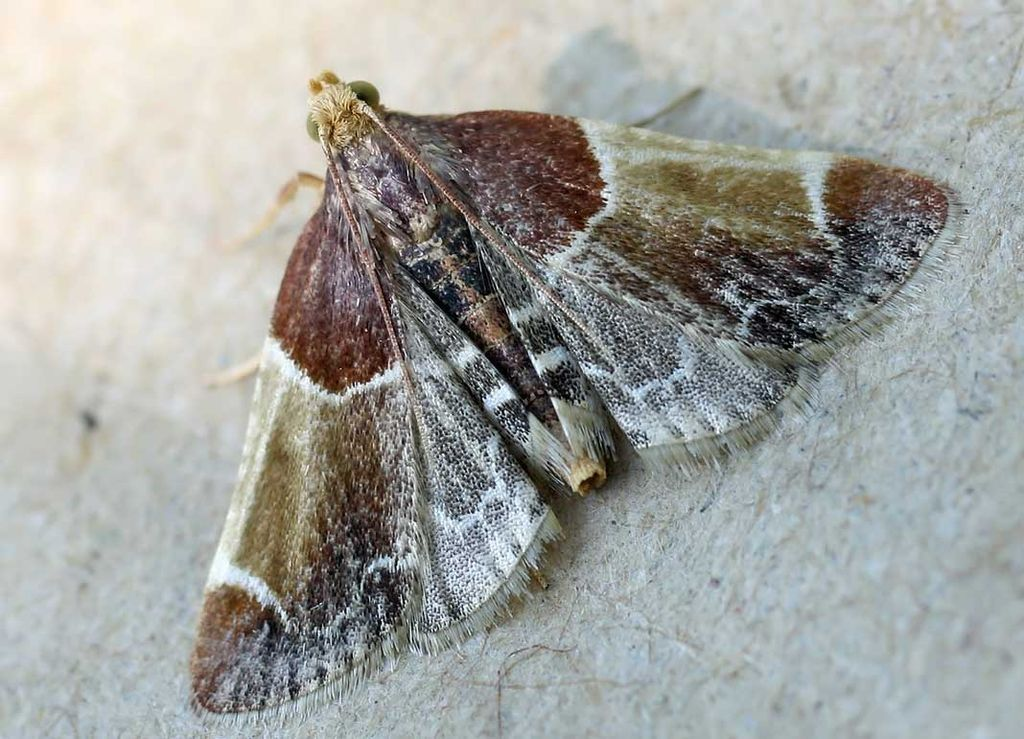

Ancova moth, or snout moth

ANOVA, ANCOVA, MANOVA – what’s the difference?

- ANOVA (Analysis of Variance): continuous outcome, categorical predictor(s)
  - one-way ANOVA: one categorical predictor
  - two-way ANOVA: two categorical predictors
  - two-way ANOVA with interaction: you get the picture!
- ANCOVA (Analysis of Covariance): continuous outcome, categorical predictor(s), at least one continuous predictor that is generally considered a nuisance (not unlike the snout moths, which are often considered pests because they share our tastes in grains)
- MANOVA (Multivariate ANOVA): multiple continuous outcomes, categorical predictor(s)

Historically these names had implications regarding the estimation methods used, but that is no longer always the case.

## Motivating Example: National Educational Longitudinal Study of Education (NELS)

Hoff considers a subset of the NELS data that contains information on math scores of a random sample of 10th graders selected from a national sample of 100 large urban public schools. We plot the math scores $y_{ij}$ of the $n_j$ students in each school $j$, ranked by the average score.

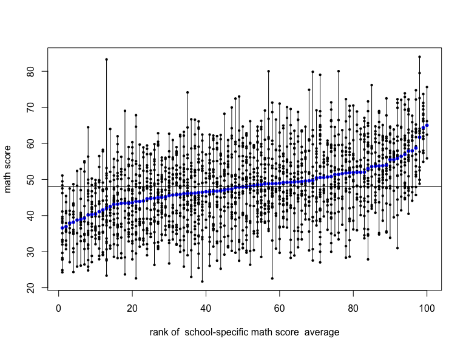

- The school-specific averages range from 36.58 to 65.02, with 48.13 the average of all 100 school averages (weighting each school equally).
- The school-specific variances range from 21.81 to 179.69 – quite a wide range!
- The school with the highest average only contains 4 observations.

## Which school is best?

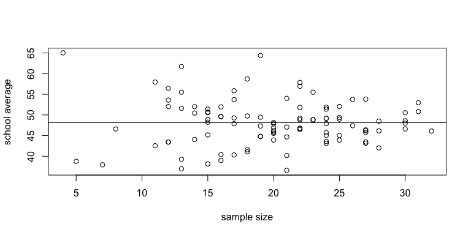

Note that the school with the highest average has the smallest sample size ($n_j=4$). Do we have strong evidence that the true mean in this school is substantially larger than that in other schools in the sample? How might we answer this question?

## ANOVA

One approach would be to fit a fixed effects ANOVA model:

```r
m1=lm(nels$mathscore~as.factor(nels$school)-1)
anova(m1)
```

```
## Analysis of Variance Table
##
## Response: nels$mathscore
##                          Df  Sum Sq Mean Sq F value    Pr(>F)
## as.factor(nels$school)  100 4654953   46550  550.66 < 2.2e-16 ***
## Residuals              1893  160024      85
## ---
## Signif. codes:  0 '***' 0.001 '**' 0.01 '*' 0.05 '.' 0.1 ' ' 1
```

Here we see clear evidence of heterogeneity in math scores across schools.

## ANOVA results

```
## #refugeeswelcome
```

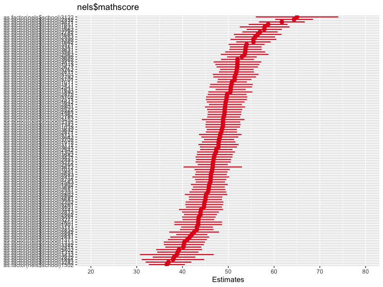

```r
library(sjPlot)
plot_model(m1,sort.est=TRUE)
```

Based on these estimates, we might conclude that the school has higher performance than some, but not all, schools.

## Random effects ANOVA

Note in the prior plot that the highest estimated mean also has a very large variance. We may wish to use shrinkage estimation in order to stabilize that and other estimates for schools in which few students provide data.

```r
library(lme4)
m2=lmer(mathscore~(1|school),data=nels)
summary(m2)
library(sjstats)
icc(m2)
```

```
## Linear mixed model fit by REML ['lmerMod']
## Formula: mathscore ~ (1 | school)
##    Data: nels
##
## REML criterion at convergence: 14685
##
## Scaled residuals:
##     Min      1Q  Median      3Q     Max
## -2.8433 -0.6630 -0.0216  0.6573  4.4035
##
## Random effects:
##  Groups   Name        Variance Std.Dev.
##  school   (Intercept) 23.20    4.817
##  Residual             84.73    9.205
## Number of obs: 1993, groups:  school, 100
##
## Fixed effects:
##             Estimate Std. Error t value
## (Intercept)  48.1050     0.5283   91.06
```

```
## # Intraclass Correlation Coefficient
##
##      Adjusted ICC: 0.215
##   Conditional ICC: 0.215
```

How do we conduct a formal test of heterogeneity in this random effects setting? Well, this is a bit more complicated than in the fixed effects setting, and we’ll return to the issue in a couple of lectures. For now just note that the school-level estimated variance is not small.

## Bringing SES into the mix

NELS contains a measure of socioeconomic status (SES) for each student. We generally expect some degree of correlation between SES and math score (people who are good at math often can get good jobs, and then have kids who may inherit math talents; rich parents may have more time and resources to devote to their kids), though of course the relationship is not deterministic (there are plenty of math whizzes who did not have rich parents, and there are plenty of rich parents who have kids who do not make good math scores).

One way to assess how SES is related to math score is to examine this association in an ANCOVA model, allowing school-specific intercepts while including SES as a covariate $x_{ij}$:

$$y_{ij}=\beta_{0j}+\beta_1x_{ij} + \varepsilon_{ij}.$$

In this model, we estimate the same effect of SES for each school.

One concern is whether SES has the same relationship with math scores in all schools. For example, some schools may have less of a disparity in scores across levels of SES than others.

How do we get good estimates of the school-specific slopes?

## School-specific slopes

Building on our knowledge of random intercept models, we could consider the following estimates.

- $\widehat{\beta}_j=\widehat{\beta}_j^{OLS}=(X_j'X_j)^{-1}X_j'y_j$, relying only on the data from school $j$
- $\widehat{\beta}_j=\widehat{\beta}^{POOL}=(X'X)^{-1}X'y$, using all the data and pooling across schools
- $\widehat{\beta}_j=w_j\widehat{\beta}_j^{OLS} + (1-w_j)\widehat{\beta}^{POOL}$, doing something in between

## School-specific slopes

One alternative to separate linear regression models for each school is fitting a single model with school-specific slopes and intercepts. These factors could be fixed or random effects. First, let’s consider the fixed effects approach.

$$y_{ij}=\beta_{0,j}+\beta_{1,j}x_{ij}+\varepsilon_{ij}$$

If we wish to evaluate whether there is heterogeneity across schools, an easy approach is to fit the model as a linear regression using indicator variables as follows.

$$y_{ij}=\beta_0+\alpha_j + \beta_1x_{ij} \gamma_jx_{ij} + \varepsilon_{ij},$$
where we assume $\alpha_J=\gamma_J=0$ (reference cell coding).

In this case, a (J-1) df test can be used to evaluate the hypothesis $H_0: \gamma_j=0$, which corresponds to a constant effect of SES across groups (given by $\beta_1$).

ANOVA, ANCOVA, and regression models with correlated errors can be considered in the framework of the *linear mixed effects model*. This modeling framework is convenient for consideration of many hierarchical models with continuous outcomes and can be extended to outcomes following distributions in the exponential family.

## data

also we could maybe get the george and rockova data here?

check [data](http://www.stat.washington.edu/~hoff/Book/Data/data/chapter11.r) – what is kristian pulling from there – rmvnorm is it.

## hmm

not liking peter’s notes really here. just move straight to lme? notes8 in my longitudinal class has the MLM formulation of the linear mixed effects model. Maybe pull my 440 notes in here? Not great binary.

Notes6.pdf from my 767 class has the general theoretical framework. Combine with Hoff for motivation? Hoff is better but not perfect either. so ha.